# Analysis of Damage by Sever Weather Events on Population Health and the Economy

JimySweettooth

April 25, 2015

## Synopsis

Tornadoes are the leading cause of Weather related human health hazards in the US, while Floods produce the most expensive economic consequence, according to the analysis of Weather Events recorded by the US National Oceanic and Atmospheric ADministration’s (NOAA) storm database from 1950 through 2011.

## Data processing

The following sources were used for the analysis.

To address the above questions, we make use of [Storm data](https://d396qusza40orc.cloudfront.net/repdata%2Fdata%2FStormData.csv.bz2) [47 Mb]. Additional documentation on this dataset can be found on the [National Weather Service](https://d396qusza40orc.cloudfront.net/repdata%2Fpeer2_doc%2Fpd01016005curr.pdf) and the [National Climatic Data Center Storm Events FAQ](https://d396qusza40orc.cloudfront.net/repdata%2Fpeer2_doc%2FNCDC%20Storm%20Events-FAQ%20Page.pdf).

First, we load the relevant data by taking the compressed file titled *repdata-data-StormData.csv.bz2* in the working directory and unzip it with the command,

```r
#R.utils is a required package for commands 'download.file' and 'bunzip2'
library(R.utils, warn.conflicts=FALSE)

fileUrl <-
    "http://d396qusza40orc.cloudfront.net/repdata%2Fdata%2FStormData.csv.bz2"
destFile <- "repdata_data_StormData.csv.bz2"

if (!file.exists(destFile)) {
  download.file(fileUrl, destfile=destFile)
  bunzip2(destFile, overwrite=TRUE,remove=FALSE)
} else {
  bunzip2(destFile, overwrite=TRUE,remove=FALSE)
  }
```

Next, we uncompressed the data to a csv file and load it into R as *Storm*, and then delete the csv file to conserve space on the local hard drive:

```r
Storm <- read.csv("repdata_data_StormData.csv", header=TRUE)
file.remove("repdata_data_StormData.csv")
```

Before we could conduct any analysis, we needed to clean up some select fields. In this case, the Event Type field was cleaned to reduce the number of unique event types.

```r
# number of unique event types
length(unique(Storm$EVTYPE))
# translate all letters to lowercase
event_types <- tolower(Storm$EVTYPE)
# replace all punct. characters with a space
event_types <- gsub("[[:blank:][:punct:]+]", " ", event_types)
length(unique(event_types))
# update the data frame
Storm$EVTYPE <- event_types
```

## Results

### I. Which types of events are most harmful with respect to population health?

To find the event types that are most harmful to population health, the number of casualties are aggregated by the event type.

```r
library(plyr)
casualties <- ddply(Storm, .(EVTYPE), summarize,
                    fatalities = sum(FATALITIES),
                    injuries = sum(INJURIES))

# Find events that caused most death and injury
fatal_events <- head(casualties[order(casualties$fatalities, decreasing = T), ], 10)
injury_events <- head(casualties[order(casualties$injuries, decreasing = T), ], 10)
```

Top 10 events that caused largest number of deaths are

```r
fatal_events[, c("EVTYPE", "fatalities")]
```

```
##             EVTYPE fatalities
## 697        tornado       4481
## 104 excessive heat       1047
## 220           heat        707
## 717      tstm wind        412
## 122    flash flood        400
## 382      lightning        398
## 138          flood        210
## 222      heat wave        172
## 112   extreme cold        145
## 290      high wind        134
```

Top 10 events that caused most number of injuries are

```r
injury_events[, c("EVTYPE", "injuries")]
```

```
##                 EVTYPE injuries
## 697            tornado    76998
## 138              flood     6480
## 717          tstm wind     5463
## 104     excessive heat     3283
## 382          lightning     2589
## 356          ice storm     1866
## 122        flash flood      986
## 815       winter storm      962
## 653 thunderstorm winds      908
## 220               heat      878
```

The following plot shows top dangerous weather event types.

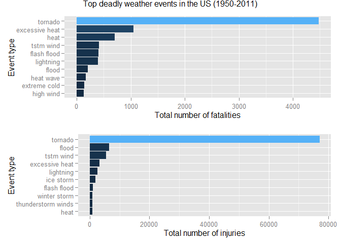

```r
library(ggplot2)
library(gridExtra)
# Set the levels in order
p1 <- ggplot(data=fatal_events,
             aes(x=reorder(EVTYPE, fatalities), y=fatalities, fill=fatalities)) +
    geom_bar(stat="identity") +
    coord_flip() +
    ylab("Total number of fatalities") +
    xlab("Event type") +
    theme(legend.position="none")

p2 <- ggplot(data=injury_events,
             aes(x=reorder(EVTYPE, injuries), y=injuries, fill=injuries)) +
    geom_bar(stat="identity") +
    coord_flip() +
    ylab("Total number of injuries") +
    xlab("Event type") +
    theme(legend.position="none")

grid.arrange(p1, p2, main="Top deadly weather events in the US (1950-2011)")
```

### II. Which types of events have the greatest economic consequences?

Economic consequences are quantified using the variables titled *PROPDMG* and and *CROPDMG*. This time, we must make use of the factor variables titled *PROPDMGEXP* and *CROPDMGEXP* in order to put *PROPDMG* and *CROPDMG* in the accurate dollar amounts (e.g. *K*, *M*, and *B* stand for *Thousands*, *Millions*, and *Billions* respectively).

The first step in the analysis is to calculate the property and crop damage for each event.

```r
exp_transform <- function(e) {
    # h -> hundred, k -> thousand, m -> million, b -> billion
    if (e %in% c('h', 'H'))
        return(2)
    else if (e %in% c('k', 'K'))
        return(3)
    else if (e %in% c('m', 'M'))
        return(6)
    else if (e %in% c('b', 'B'))
        return(9)
    else if (!is.na(as.numeric(e))) # if a digit
        return(as.numeric(e))
    else if (e %in% c('', '-', '?', '+'))
        return(0)
    else {
        stop("Invalid exponent value.")
    }
}
```

```r
prop_dmg_exp <- sapply(Storm$PROPDMGEXP, FUN=exp_transform)
Storm$prop_dmg <- Storm$PROPDMG * (10 ** prop_dmg_exp)
crop_dmg_exp <- sapply(Storm$CROPDMGEXP, FUN=exp_transform)
Storm$crop_dmg <- Storm$CROPDMG * (10 ** crop_dmg_exp)
```

```r
# Compute the economic loss by event type
library(plyr)
econ_loss <- ddply(Storm, .(EVTYPE), summarize,
                   prop_dmg = sum(prop_dmg),
                   crop_dmg = sum(crop_dmg))

# filter out events that caused no economic loss
econ_loss <- econ_loss[(econ_loss$prop_dmg > 0 | econ_loss$crop_dmg > 0), ]
prop_dmg_events <- head(econ_loss[order(econ_loss$prop_dmg, decreasing = T), ], 10)
crop_dmg_events <- head(econ_loss[order(econ_loss$crop_dmg, decreasing = T), ], 10)
```

Top 10 events that caused most property damage (in dollars) are as follows

```r
prop_dmg_events[, c("EVTYPE", "prop_dmg")]
```

```
##                 EVTYPE     prop_dmg
## 122        flash flood 6.819097e+13
## 653 thunderstorm winds 2.086532e+13
## 697            tornado 1.059905e+12
## 190               hail 3.040921e+11
## 382          lightning 1.723823e+11
## 150           flooding 5.920825e+10
## 249         heavy snow 1.767132e+10
## 138              flood 1.067542e+10
## 333          hurricane 8.829563e+09
## 815       winter storm 5.317774e+09
```

Similarly, the events that caused biggest crop damage are

```r
crop_dmg_events[, c("EVTYPE", "crop_dmg")]
```

```
##           EVTYPE   crop_dmg
## 74       drought 7275081000
## 480  river flood 5029459000
## 356    ice storm 5013448500
## 333    hurricane 2292930000
## 138        flood 2048191050
## 190         hail 1355816280
## 112 extreme cold 1158283000
## 122  flash flood  546632600
## 156       freeze  408875000
## 220         heat  401285000
```

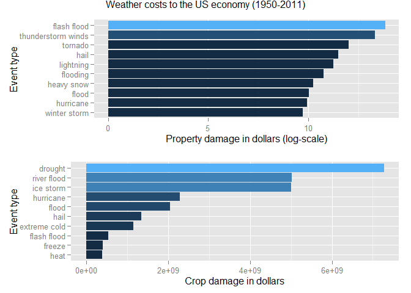

```r
library(ggplot2)
library(gridExtra)
# Set the levels in order
p1 <- ggplot(data=prop_dmg_events,
             aes(x=reorder(EVTYPE, prop_dmg), y=log10(prop_dmg), fill=prop_dmg )) +
    geom_bar(stat="identity") +
    coord_flip() +
    xlab("Event type") +
    ylab("Property damage in dollars (log-scale)") +
    theme(legend.position="none")

p2 <- ggplot(data=crop_dmg_events,
             aes(x=reorder(EVTYPE, crop_dmg), y=crop_dmg, fill=crop_dmg)) +
    geom_bar(stat="identity") +
    coord_flip() +
    xlab("Event type") +
    ylab("Crop damage in dollars") +
    theme(legend.position="none")

grid.arrange(p1, p2, main="Weather costs to the US economy (1950-2011)")
```

The data shows that flash floods and thunderstorm winds cost the largest property damages among weather-related natural diseasters. Note that, due to untidy nature of the available data, type *flood* and *flash flood* are separate values and should be merged for more accurate data-driven conclusions.

The most severe weather event in terms of crop damage is the *drought*